# Stat435_HW5

Su Huang

2022-06-04

### Problem 1

#### a).

$$y_i = \beta_0 + \beta_1z_{i1} + \beta_2z_{i2} + ... + \beta_Mz_{iM} +
\epsilon_i$$

#### b).

$$z_{im} = \phi_{1m}x_{i1} + \phi_{2m}x_{i2} + ... + \phi_{pm}x_{ip} \\
\text{Plug this equation to part a:} \\
y_i = \beta_0 + \beta_1(\phi_{11}x_{i1} + \phi_{21}x_{i2} + ... +
\phi_{p1}x_{ip})\\
+ \beta_2(\phi_{12}x_{i1} + \phi_{22}x_{i2} + ... + \phi_{p2}x_{ip}) \\
+ ... + \beta_M(\phi_{1M}x_{i1} + \phi_{2M}x_{i2} + ... +
\phi_{pM}x_{ip}) + \epsilon_i$$

#### c).

$$y_i = \beta_0 + \beta_1\phi_{11}x_{i1} + \beta_1\phi_{21}x_{i2} + ... +
\beta_1\phi_{p1}x_{ip}\\
+ \beta_2\phi_{12}x_{i1} + \beta_2\phi_{22}x_{i2} + ... +
\beta_2\phi_{p2}x_{ip} \\
+ ... + \beta_M\phi_{1M}x_{i1} + \beta_M\phi_{2M}x_{i2} + ... +
\beta_M\phi_{pM}x_{ip} + \epsilon_i \\
= \beta_0 +
(\beta_1\phi_{11}+\beta_2\phi_{12}+...+\beta_M\phi_{1M})x_{i1} +
(\beta_1\phi_{21} + \beta_2\phi_{22} + ... + \beta_M\phi_{2M})x_{i2} \\
+...+ (\beta_1\phi_{p1} + \beta_2\phi_{p2} +...+ \beta_M\phi_{pM})x_{ip}
+ \epsilon_i \\
\beta_1\phi_{a1}+\beta_2\phi_{a2}+...+\beta_M\phi_{aM} \text{ is a
constant for a > 0}
\\
\text{ We can see the principal components regression model is linear in
the columns of X.}$$

#### d).

It’s False. Since we only use the first M PC instead of the whole columns of X, if we choose the different PC, which may give us different prediction than using the columns of X. It turns out that constraining each Z to be uncorrelated with other Z is equivalent to constraining the direction to be orthogonal and giving us less variance.

### Problem 2

#### a).

```r
matrix = array(rnorm(320), dim=c(20,16))

matrix[1:10, 16] <- 1
matrix[11:20, 16] <- 2
```

```r
# cluster 1
# left hand side:
sum = 0
for (i in 1:10) {
  for (i2 in 1:10) {
    for (j in 1:15) {
      sum = sum + (matrix[i, j] - matrix[i2, j])^2
    }
  }
}
c1_left <- sum/10

# right hand side:
sum2 <- 0
for (i in 1:10) {
  for (j in 1:15) {
      sum2 = sum2 + (matrix[i, j] - mean(matrix[1:10, j]))^2
  }
}
c1_right <- sum2 * 2

c1_right
```

```
## [1] 290.7432
```

```r
c1_left
```

```
## [1] 290.7432
```

```r
c1_right - c1_left
```

```
## [1] -5.684342e-14
```

```r
# cluster 2
# left hand side:
sum = 0
for (i in 11:20) {
  for (i2 in 11:20) {
    for (j in 1:15) {
      sum = sum + (matrix[i, j] - matrix[i2, j])^2
    }
  }
}
c1_left <- sum/10

# right hand side:
sum2 <- 0
for (i in 11:20) {
  for (j in 1:15) {
      sum2 = sum2 + (matrix[i, j] - mean(matrix[11:20, j]))^2
  }
}
c1_right <- sum2 * 2

c1_right
```

```
## [1] 281.2636
```

```r
c1_left
```

```
## [1] 281.2636
```

```r
c1_right - c1_left
```

```
## [1] -5.684342e-14
```

The left side is equal to the right side for both clusters.

#### b).

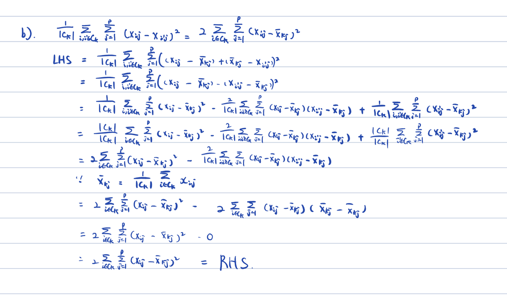

```r
knitr::include_graphics("2b.jpeg")
```

### Problem 3

#### a).

```r
set.seed(1)
df <- data.frame(replicate(50, rnorm(20, mean = 1,  sd = 1))) %>%
    rbind(data.frame(replicate(50, rnorm(20, mean = 2, sd = 1)))) %>%
    rbind(data.frame(replicate(50, rnorm(20, mean = 3, sd = 1)))) %>%
    as.tibble %>%
    mutate(id = row_number(),
           class = ifelse(id <= 20, 'a',
                          ifelse(id <= 40, 'b',
                                 'c'))) %>%
    select(-id)
```

#### b).

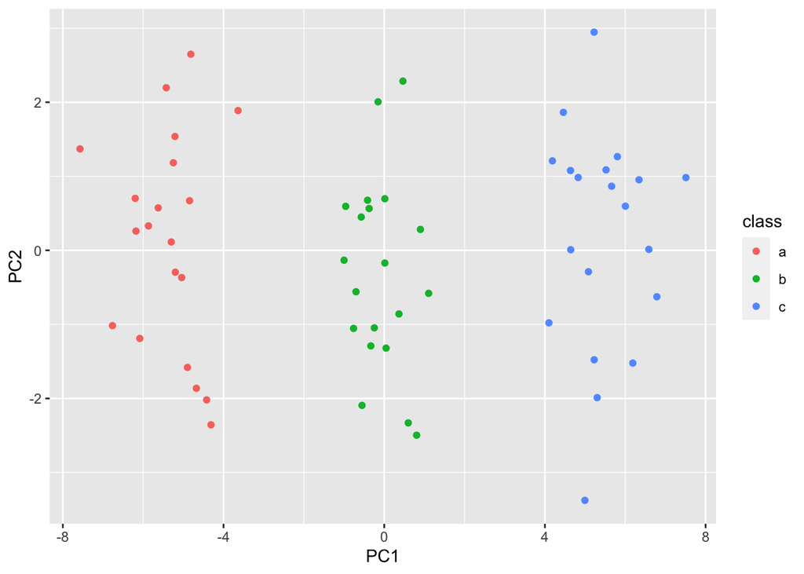

```r
pr.out <- prcomp(df %>% select(-class), scale = TRUE)
ggplot(data.frame(PC1 = pr.out$x[,1], PC2 = pr.out$x[,2], class = df$class),
       aes(x = PC1, y = PC2, col = class)) + geom_point()
```

#### c).

```r
km.out <- kmeans(df %>% select(-class), 3, nstart = 20)
table(df$class, km.out$cluster)
```

```
##
##      1  2  3
##   a  0  0 20
##   b 20  0  0
##   c  0 20  0
```

The k-means clusters perform perfect on the observations.

#### d).

```r
km.out2 <- kmeans(df %>% select(-class), 2, nstart = 20)
table(df$class, km.out2$cluster)
```

```
##
##      1  2
##   a  0 20
##   b  0 20
##   c 20  0
```

The observations a and b are included into one cluster (cluster 2)

#### e).

```r
km.out4 <- kmeans(df %>% select(-class), 4, nstart = 20)
table(df$class, km.out4$cluster)
```

```
##
##      1  2  3  4
##   a  9 11  0  0
##   b  0  0  0 20
##   c  0  0 20  0
```

The observation a is separated into the cluster 1 and 2.

#### f).

```r
km.outpca <- kmeans(pr.out$x[,1:2], 3, nstart = 20)
table(df$class, km.outpca$cluster)
```

```
##
##      1  2  3
##   a  0 20  0
##   b 20  0  0
##   c  0  0 20
```

The k-means clusters perform perfect on the observations.

#### g).

```r
km.outscale <- kmeans(scale(df %>% select(-class)), 3, nstart = 20)
table(df$class, km.outscale$cluster)
```

```
##
##      1  2  3
##   a  0  0 20
##   b 20  0  0
##   c  0 20  0
```

It performs as perfect as part c

### Problem 4

```r
library(ISLR2)
library(e1071)
#head(OJ)
dim(OJ)
```

```
## [1] 1070   18
```

#### a).

```r
set.seed(1)
is.train <- sample(dim(OJ)[1],800)
OJ.train <- OJ[is.train, ]
OJ.test <- OJ[-is.train, ]
```

#### b).

```r
set.seed(1)
svmfit <- svm(Purchase ~ ., data = OJ.train, kernel = "linear", cost = 0.01)
summary(svmfit)
```

```
##
## Call:
## svm(formula = Purchase ~ ., data = OJ.train, kernel = "linear", cost = 0.01)
##
##
## Parameters:
##    SVM-Type:  C-classification
##  SVM-Kernel:  linear
##        cost:  0.01
##
## Number of Support Vectors:  435
##
##  ( 219 216 )
##
##
## Number of Classes:  2
##
## Levels:
##  CH MM
```

The number of support vectors is 435 which is a considerable number since we only have 800 data in training set. The number of classes is 2 with level of CH and MM.

#### c).

```r
pred_train <- predict(svmfit, OJ.train)
table(predict = pred_train, truth = OJ.train$Purchase)
```

```
##        truth
## predict  CH  MM
##      CH 420  75
##      MM  65 240
```

```r
print(paste("The training error for train is ", (65+75) /800))
```

```
## [1] "The training error for train is  0.175"
```

```r
pred_test <- predict(svmfit, OJ.test)
table(predict = pred_test, truth = OJ.test$Purchase)
```

```
##        truth
## predict  CH  MM
##      CH 153  33
##      MM  15  69
```

```r
print(paste("The test error is ", (15+33) / 270))
```

```
## [1] "The test error is  0.177777777777778"
```

#### d).

```r
set.seed(1)
tune.out.linear <- tune(svm, Purchase ~., data = OJ.train, kernel = "linear",
                ranges = list(cost = c(0.001, 0.01, 0.1, 1, 5, 10)))
summary(tune.out.linear)
```

```
##
## Parameter tuning of 'svm':
##
## - sampling method: 10-fold cross validation
##
## - best parameters:
##  cost
##   0.1
##
## - best performance: 0.1725
##
## - Detailed performance results:
##    cost   error dispersion
## 1 1e-03 0.31250 0.04124790
## 2 1e-02 0.17625 0.02853482
## 3 1e-01 0.17250 0.03162278
## 4 1e+00 0.17500 0.02946278
## 5 5e+00 0.17250 0.03162278
## 6 1e+01 0.17375 0.03197764
```

The optimal cost is 0.1/5 with error 0.17250